# $\color{brown}{\text{Stock Price Forecasting: A Data-Driven Approach to Uncover Market Trends}}$

In this project, I aim to predict the future stock prices of Amazon (AMZN), one of the most influential players in the global market. Amazon, with its vast market presence and influence, provides a rich and dynamic dataset for analysis. Using historical data over the past five years, sourced from Yahoo Finance, the project involves applying various time series forecasting models to understand and predict Amazon's stock price movements.

```python
!pip install statsmodels
```

```python
!pip install mplfinance -q
```

```
     ━━━━━━━━━━━━━━━━━━━━━━━━━━━━━━━━━━━━━━━━ 75.0/75.0 kB 1.4 MB/s eta 0:00:00
```

### $\color{purple}{\text{Problem Statement }}$:

To predict the future stock prices of company based on historical stock data. The objective here is to build a model that accurately forecasts the next day's closing price or predicts the overall trend in stock prices.

```python
from matplotlib import dates
import matplotlib.pyplot as plt
import mplfinance as mpf
import numpy as np
import pandas as pd
import yfinance as yf
import seaborn as sb
```

```python
import warnings
warnings.filterwarnings('ignore')
```

### $\color{purple}{\text{Data Collection}}$

Amazon's stock, known for its robust performance and significant market impact, presents a fascinating subject for price analysis and forecasting. As a leading player in e-commerce, cloud computing, and digital streaming, Amazon's stock encapsulates the pulse of both technological innovation and consumer trends. Its price movements offer valuable insights into broader market dynamics, making it an ideal candidate for predictive financial analysis. By analyzing Amazon's stock price, investors and data scientists can uncover patterns and indicators that are crucial for making informed investment decisions. This analysis not only aids in understanding Amazon's corporate health and strategy but also serves as a barometer for the tech industry and consumer behavior, highlighting the interplay between technology adoption and market performance. The study of Amazon's stock is therefore not just about predicting financial returns; it's a window into the evolving landscape of global commerce and technology.For data streaming Yahoo finance is used.

```python
df = yf.download('AMZN',start='2019-01-01',end='2023-12-15')
df.to_csv('amzn.csv', index=False)
df.head(5)
```

```
[*********************100%%**********************]  1 of 1 completed
```

| Date | Open | High | Low | Close | Adj Close | Volume |
| --- | --- | --- | --- | --- | --- | --- |
| 2019-01-02 | 73.260002 | 77.667999 | 73.046501 | 76.956497 | 76.956497 | 159662000 |
| 2019-01-03 | 76.000504 | 76.900002 | 74.855499 | 75.014000 | 75.014000 | 139512000 |
| 2019-01-04 | 76.500000 | 79.699997 | 75.915497 | 78.769501 | 78.769501 | 183652000 |
| 2019-01-07 | 80.115501 | 81.727997 | 79.459503 | 81.475502 | 81.475502 | 159864000 |
| 2019-01-08 | 83.234497 | 83.830498 | 80.830498 | 82.829002 | 82.829002 | 177628000 |

```python
data = df.resample('D').ffill()
data.head(7)
```

| Date | Open | High | Low | Close | Adj Close | Volume |
| --- | --- | --- | --- | --- | --- | --- |
| 2019-01-02 | 73.260002 | 77.667999 | 73.046501 | 76.956497 | 76.956497 | 159662000 |
| 2019-01-03 | 76.000504 | 76.900002 | 74.855499 | 75.014000 | 75.014000 | 139512000 |
| 2019-01-04 | 76.500000 | 79.699997 | 75.915497 | 78.769501 | 78.769501 | 183652000 |
| 2019-01-05 | 76.500000 | 79.699997 | 75.915497 | 78.769501 | 78.769501 | 183652000 |
| 2019-01-06 | 76.500000 | 79.699997 | 75.915497 | 78.769501 | 78.769501 | 183652000 |
| 2019-01-07 | 80.115501 | 81.727997 | 79.459503 | 81.475502 | 81.475502 | 159864000 |
| 2019-01-08 | 83.234497 | 83.830498 | 80.830498 | 82.829002 | 82.829002 | 177628000 |

```python
data.info()
```

```
<class 'pandas.core.frame.DataFrame'>
DatetimeIndex: 1808 entries, 2019-01-02 to 2023-12-14
Freq: D
Data columns (total 6 columns):
 #   Column     Non-Null Count  Dtype
---  ------     --------------  -----
 0   Open       1808 non-null   float64
 1   High       1808 non-null   float64
 2   Low        1808 non-null   float64
 3   Close      1808 non-null   float64
 4   Adj Close  1808 non-null   float64
 5   Volume     1808 non-null   int64
dtypes: float64(5), int64(1)
memory usage: 98.9 KB
```

```python
data.describe().round(2)
```

|  | Open | High | Low | Close | Adj Close | Volume |
| --- | --- | --- | --- | --- | --- | --- |
| count | 1808.00 | 1808.00 | 1808.00 | 1808.00 | 1808.00 | 1.808000e+03 |
| mean | 127.40 | 128.89 | 125.69 | 127.31 | 127.31 | 7.797790e+07 |
| std | 31.37 | 31.62 | 30.95 | 31.23 | 31.23 | 3.662936e+07 |
| min | 73.26 | 76.90 | 73.05 | 75.01 | 75.01 | 1.762600e+07 |
| 25% | 95.44 | 96.45 | 94.17 | 95.20 | 95.20 | 5.378800e+07 |
| 50% | 126.70 | 128.49 | 124.99 | 126.59 | 126.59 | 6.698845e+07 |
| 75% | 158.52 | 160.07 | 156.15 | 158.12 | 158.12 | 9.269400e+07 |
| max | 187.20 | 188.65 | 184.84 | 186.57 | 186.57 | 3.113460e+08 |

```python
data.columns
```

```
Index(['Open', 'High', 'Low', 'Close', 'Adj Close', 'Volume'], dtype='object')
```

### $\color{purple}{\text{Data Preprocessing}}$:

Clean and preprocess the collected data to make it suitable for analysis and modeling.

```python
data.isna().sum()
```

```
Open         0
High         0
Low          0
Close        0
Adj Close    0
Volume       0
dtype: int64
```

# Trend Analysis

Stock Prices

- The plots for 'Close', 'Open', 'High', and 'Low' prices indicate the price movement of Amazon's stock over time.
- There appears to be a general trend in the data, with some periods of higher volatility. Basically convergence and divergence between the price lines, which can indicate periods of stability or volatility.

Trading Volume

- The trading volume shows variation over time, with some peaks indicating days of particularly high trading activity.
- There is no immediately obvious consistent pattern in the trading volume, but some peaks in volume appear to coincide with more significant changes in stock price.

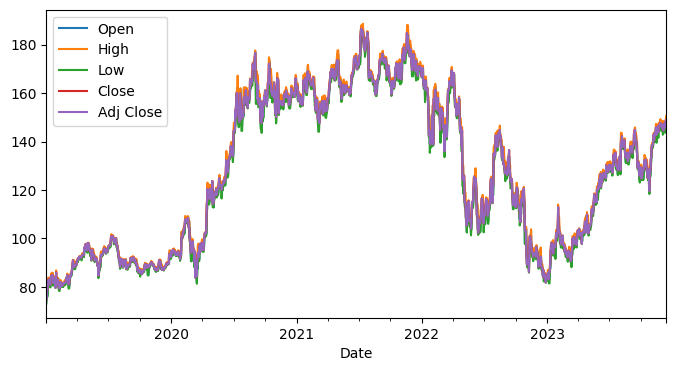

```python
data.iloc[:,:-1].plot(figsize = (8,4))
```

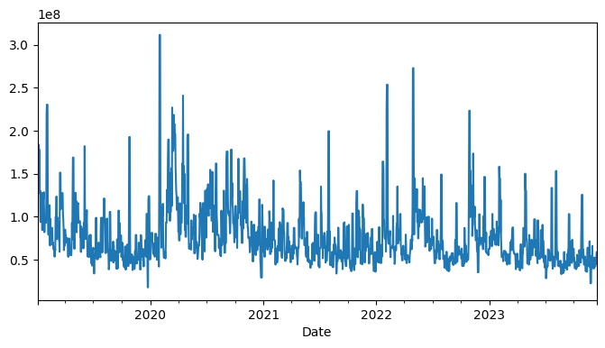

```python
data.iloc[:,-1].plot(figsize=(8,4))
```

[figure not shown]

```python
(data
 [['Open', 'Close']]
 .plot(figsize = (8,4)))
```

[figure not shown]

```python
(data
 [['High', 'Low']]
 #.pipe(fix_col)
 .plot(figsize = (8,4)))
```

[figure not shown]

```python
features = ['Open', 'High', 'Low', 'Close', 'Volume']

plt.subplots(figsize=(20,10))

for i, col in enumerate(features):
  plt.subplot(2,3,i+1)
  sb.distplot(data[col])
plt.show()
```

[figure not shown]

```python
features = ['Open', 'High', 'Low', 'Close', 'Volume']
plt.subplots(figsize=(20,10))
for i, col in enumerate(features):
  plt.subplot(2,3,i+1)
  sb.boxplot(data[col])
plt.show()
```

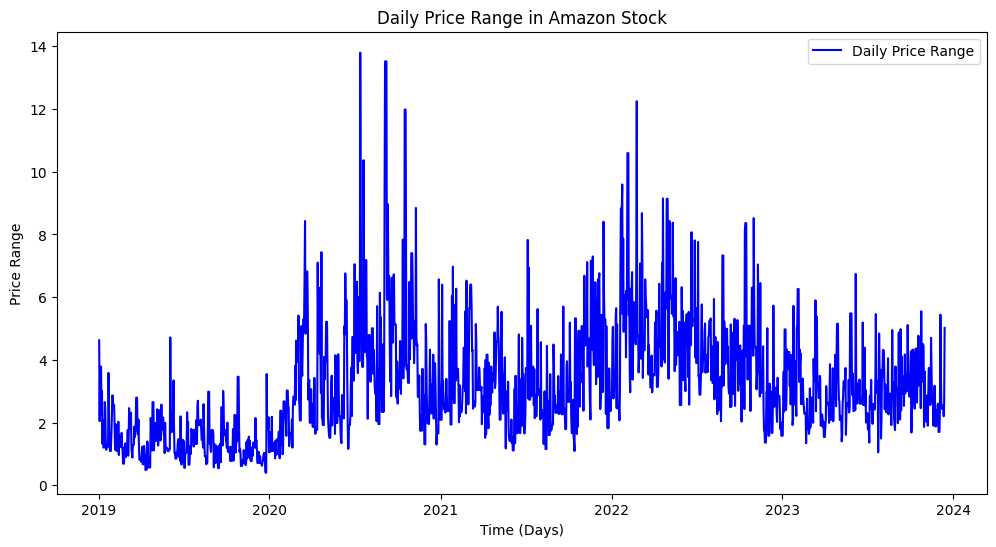

```python
data['Price_range'] = data['High']- data['Low']

# Plotting the daily price range
plt.figure(figsize=(12, 6))
plt.plot(data['Price_range'], label='Daily Price Range', color='blue')
plt.title('Daily Price Range in Amazon Stock')
plt.ylabel('Price Range')
plt.xlabel('Time (Days)')
plt.legend()
plt.show()
```

# Price Fluctuations Analysis

The plot above shows the daily price range (the difference between the 'High' and 'Low' prices) for Amazon's stock.

- Volatility: The size of the daily price range can be an indicator of volatility. Larger ranges suggest more volatility on that day.
- Trends: There are periods with consistently higher price ranges, indicating more volatility during those times.

```python
data.head(10)
```

| Date | Open | High | Low | Close | Adj Close | Volume | Price_range |
| --- | --- | --- | --- | --- | --- | --- | --- |
| 2019-01-02 | 73.260002 | 77.667999 | 73.046501 | 76.956497 | 76.956497 | 159662000 | 4.621498 |
| 2019-01-03 | 76.000504 | 76.900002 | 74.855499 | 75.014000 | 75.014000 | 139512000 | 2.044502 |
| 2019-01-04 | 76.500000 | 79.699997 | 75.915497 | 78.769501 | 78.769501 | 183652000 | 3.784500 |
| 2019-01-05 | 76.500000 | 79.699997 | 75.915497 | 78.769501 | 78.769501 | 183652000 | 3.784500 |
| 2019-01-06 | 76.500000 | 79.699997 | 75.915497 | 78.769501 | 78.769501 | 183652000 | 3.784500 |
| 2019-01-07 | 80.115501 | 81.727997 | 79.459503 | 81.475502 | 81.475502 | 159864000 | 2.268494 |
| 2019-01-08 | 83.234497 | 83.830498 | 80.830498 | 82.829002 | 82.829002 | 177628000 | 3.000000 |
| 2019-01-09 | 82.649002 | 83.389999 | 82.070000 | 82.971001 | 82.971001 | 126976000 | 1.320000 |
| 2019-01-10 | 82.050499 | 83.162498 | 81.081001 | 82.810997 | 82.810997 | 130154000 | 2.081497 |
| 2019-01-11 | 82.027496 | 83.014503 | 81.810997 | 82.028000 | 82.028000 | 93724000 | 1.203506 |

```python
data.index.dtype
```

```
dtype('<M8[ns]')
```

```python
data['Year'] = data.index.year
data['dayofweek'] = data.index.dayofweek
data['day_of_month'] = data.index.day
data['week_of_month'] = np.ceil(data['day_of_month'] / 7).astype(int)
data['month'] = data.index.month
data
```

[output not shown]

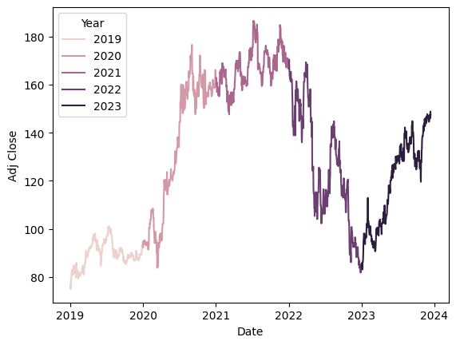

```python
import seaborn as sns
sns.lineplot(x=data.index, y='Adj Close',hue ='Year', data=data )
```

```python
year = data['Year'].unique()
year

data['DayOfYear'] = data.index.dayofyear
```

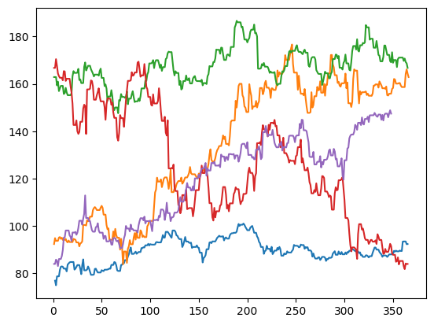

```python
for yr in year :
  yearly_data = data[data['Year'] == yr]
  plt.plot(yearly_data['DayOfYear'], yearly_data['Adj Close'],label = year)
```

```python
data
```

[output not shown]

1808 rows × 14 columns

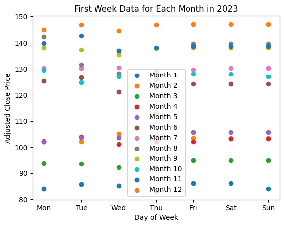

```python
wy_data = data[(data['week_of_month'] == 1) & (data['Year']==2023)]
wy_data

unique_months = wy_data.index.month.unique()
for month in unique_months:
    monthly_data = wy_data[wy_data['month'] == month]
    plt.scatter(monthly_data['dayofweek'],monthly_data['Adj Close'], label=f'Month {month}')
plt.xlabel('Day of Week')
plt.ylabel('Adjusted Close Price')
plt.title('First Week Data for Each Month in 2023')
plt.legend()
plt.xticks(ticks=range(7), labels=['Mon', 'Tue', 'Wed', 'Thu', 'Fri', 'Sat', 'Sun'])
plt.show()
```

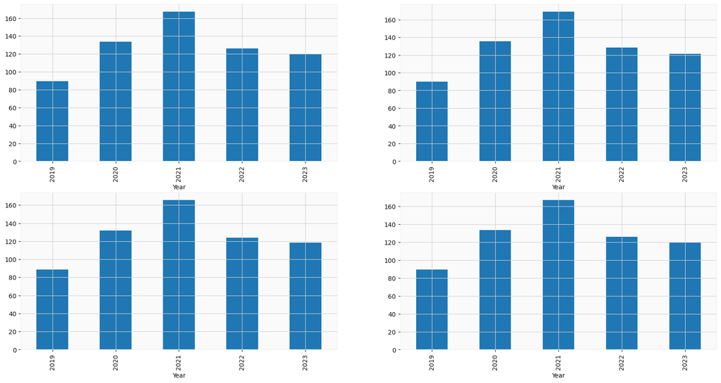

```python
data_grouped = data.groupby('Year').mean()
plt.subplots(figsize=(20,10))

for i, col in enumerate(['Open', 'High', 'Low', 'Close']):
  plt.subplot(2,2,i+1)
  data_grouped[col].plot.bar()
plt.show()
```

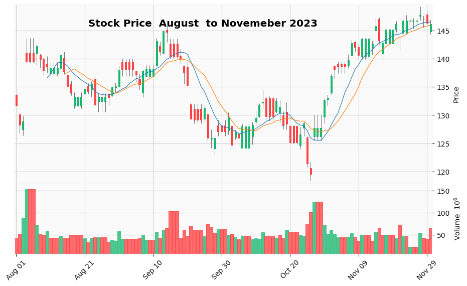

```python
mpf.plot(data['2023-08':'2023-11'],
         figratio=(10,6), type='candle',
        title= 'Stock Price  August  to Novemeber 2023',
         mav=(10,15),
         #ema=(10),
         volume = True,
         tight_layout = True, style ='yahoo',
        )
```